# Statistical Analasys of Fish Surrounding Iceland (Tölvuverkefni 3)

Óðinn Eldon Ragnarsson (oer2@hi.is), Oren Raz(orr3@hi.is)

26/3/2020

Importing libraries needed

```r
library(tidyverse)
library(readr)
library(dplyr)
library(lubridate)
library(ggplot2)
```

## a)

First we read the csv file and create a database to work with within R. We then rename the columns of the database to be more readable names. The data in question was collected by “Hafransóknarstofnun” in 1998. The data describes various properties of fish caught by trawl in around Iceland.

```r
#reading .csv file
oo <- read.csv(file = 'data98.csv', sep =',')
oo <- subset(oo, select = -c(recid,vf))
# Change the names to more usefull names
oo = oo%>%rename("area" = "reit",
                   "sub_area" = "smrt",
                   "trawl_num" = "tog_nr",
                   "day" = "dag",
                   "month" = "man",
                   "min_depth" = "dyp_min",
                   "max_depth" = "dyp_max",
                   "fish_num" = "nr",
                   "fish_length" = "le",
                   "fish_gender" = "ky",
                   "breeding_age" = "kt",
                   "fish_age" = "aldur",
                   "fish_mass" = "osl",
                   "gutted_mass" = "sl",
                   "liver_mass" = "li")
```

Here we define a function that converts the area code to longitude and latitude coordinates. We also create columns with the longitude and latitude of the area in question.

```r
# Function to determine the longitude and latitude
r2d <-function(r)
{
    lat <- floor(r/100)
    lon <- (r - lat * 100) %% 50
    halfb <- (r - 100 * lat - lon)/100
    lon <-  - (lon + 0.5)
    lat <- lat + 60 + halfb + 0.25
    data.frame(lat = lat, lon = lon)
}
#Creates columns of longitude and latitude based off area
reitir<-oo$area
long <- r2d(reitir)$lon
lat <- r2d(reitir)$lat
oo <- cbind(oo, long, lat)
```

Here is a very rough outline of where the area codes correspond to. The empty are in the center is Iceland.

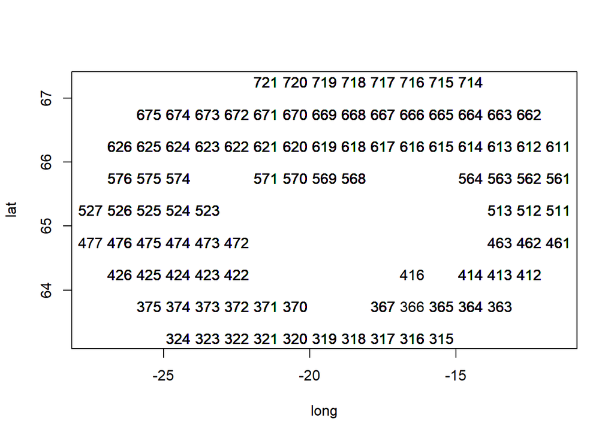

```r
plot(long,lat,type='n')
text(long,lat,as.character(reitir))
```

Next we create four quadrants representing NE, NW, SW, SE and split the areas down based on their coordinates. We also remove the variables that are no longer needed.

```r
#Creates quadrant column
oo <- oo %>%
    mutate(
        quadrant = case_when(
            long >=(-19) & lat >= 65  ~ "NE",
            long <(-19) & lat >= 65  ~ "NW",
            long <(-19) & lat < 65  ~ "SW",
            TRUE ~ "SE"))

rm(lat,long,reitir)
```

Next we create a new column in our table to say if the fish is sexually mature based of the more complex assignment of maturity. We assign the values TRUE and FALSE accordingly.

```r
oo <- mutate(oo, breeding_age2 = case_when(
    breeding_age > 1 ~ TRUE,
    breeding_age == 1  ~ FALSE
))
```

## b)

Now we construct a table that shows the total amount of sexually mature and immature fish that we caught in each area.

```r
NE <- c(nrow(filter(oo, breeding_age2 ==FALSE, quadrant == "NE")),
        nrow(filter(oo, breeding_age2 ==TRUE, quadrant == "NE")))
NW <- c(nrow(filter(oo, breeding_age2 ==FALSE, quadrant == "NW")),
        nrow(filter(oo, breeding_age2 ==TRUE, quadrant == "NW")))
SW <- c(nrow(filter(oo, breeding_age2 ==FALSE, quadrant == "SW")),
        nrow(filter(oo, breeding_age2 ==TRUE, quadrant == "SW")))
SE <- c(nrow(filter(oo, breeding_age2 ==FALSE, quadrant == "SE")),
        nrow(filter(oo, breeding_age2 ==TRUE, quadrant == "SE")))
adulthood <- c('Breeding', 'Non_breeding')
count <- tibble(adulthood,NE,NW,SW,SE)

knitr::kable(tibble(adulthood,NE,NW,SW,SE),
      align = 'ccc', table.attr = "class=\"table\"",
      format = "html")
```

| adulthood | NE | NW | SW | SE |
| --- | --- | --- | --- | --- |
| Breeding | 981 | 934 | 221 | 204 |
| Non_breeding | 215 | 394 | 508 | 224 |

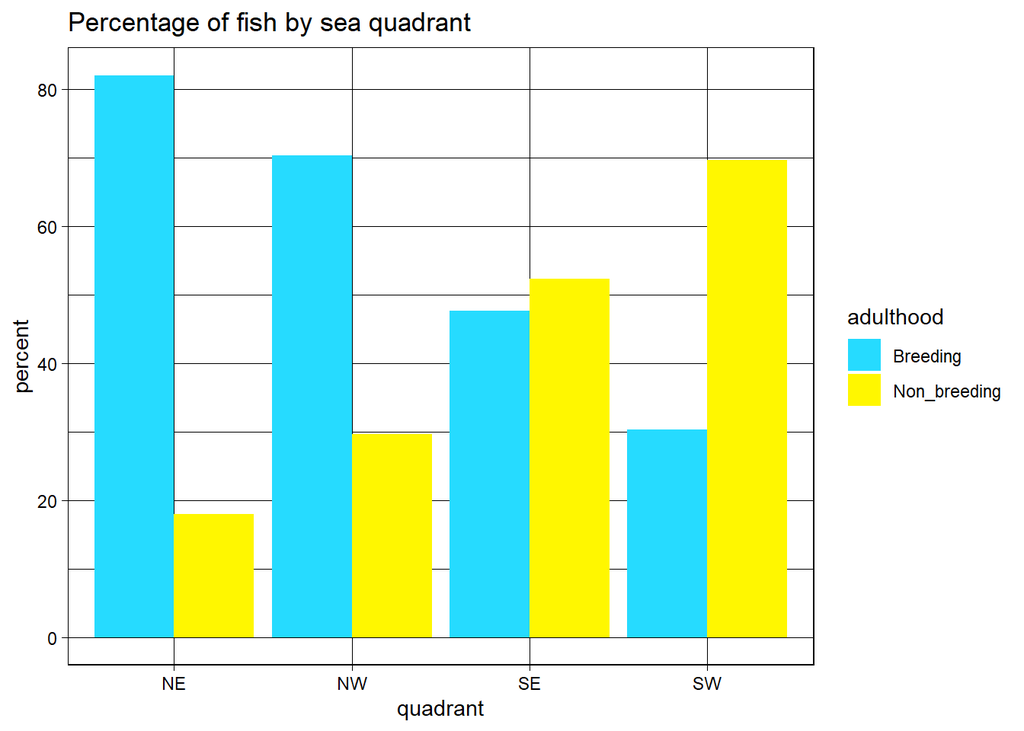

```r
count <- gather(count,key=area, value=count,
             c(NE,NW,SW,SE))

library(plyr) # needed only for ddply
count <- ddply(count,.(area),transform,percent = 100*count/sum(count))
unloadNamespace("plyr") # unloading because everything else breaks while it's loaded.

#percent of fish of breeding age by quadrant
ggplot(count, aes(fill=adulthood, y=percent, x=area)) +
  geom_bar(position="dodge", stat="identity") +
  scale_fill_manual(values=c("#26dbff", "#fff700"))+ theme_linedraw()+
  labs(title="Percentage of fish by sea quadrant",x="quadrant")
```

Here we have the amount of breeding and non breeding fish from each area. Note that the total fish from a given area doesn’t mean anything other than that Hafransóknarstofnun caught fewer fish there. The data does not specify how many trawls were pulled from each area so the fish density cannot be inferred.

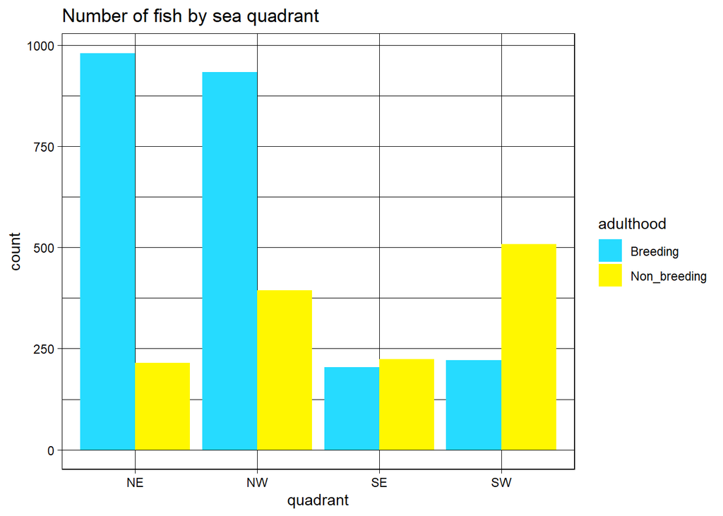

```r
#amount of fish of breeding age by quadrant
ggplot(count, aes(fill=adulthood, y=count, x=area)) +
  geom_bar(position="dodge", stat="identity") +
  scale_fill_manual(values=c("#26dbff", "#fff700"))+ theme_linedraw()+
  labs(title="Number of fish by sea quadrant",x="quadrant")
```

```r
rm(adulthood, NE,NW,SE,SW,count)
```

Based off this data it can however be seen that the mean age of the fish population is substantially larger where there are more breeding fish.

## c)

Now we create a table showing various properties of fish based on their age. Note that there were no fish in the data that were 12 year old and only one of each age group above 12. As such the standard deviation of length cannot be calculated in these cases. Also other age groups, in particular 1 and 11 only have a few fish in it. Not really enough to be confident in the standard deviation value. Other than those quirks the data is as one might expect. The average length and weight increase consistently with age until the population starts dying off.

```r
age_ordered <- tibble(length = oo$fish_length,weight = oo$fish_mass,
                      age = oo$fish_age)[order(oo$fish_age),]

# creating empty vectors to be fed in a loop
count_by_age <- c()
AvgW_by_age <- c()
AvgL_by_age <- c()
sd_by_age <- c()
age <- c()
for (i in 1: max(age_ordered$age)) {
  count_by_age <- append(count_by_age, nrow(filter(age_ordered, age == i)))
  AvgW_by_age <- append(AvgW_by_age, mean(filter(age_ordered, age == i)$weight))
  AvgL_by_age <- append(AvgL_by_age, mean(filter(age_ordered, age == i)$length))
  sd_by_age <- append(sd_by_age, sd(filter(age_ordered, age == i)$length))
  age <- append(age, i)
}
# creating table
fish_by_age <- tibble(age,
  count = count_by_age, Avg_Weight=AvgW_by_age,Avg_length = AvgL_by_age, sd_len =sd_by_age)

knitr::kable(fish_by_age,
      align = 'ccc', table.attr = "class=\"table\"",
      format = "html")
```

| age | count | Avg_Weight | Avg_length | sd_len |
| --- | --- | --- | --- | --- |
| 1 | 3 | 102.0000 | 22.66667 | 2.081666 |
| 2 | 76 | 165.5395 | 26.30263 | 3.723868 |
| 3 | 632 | 529.3180 | 38.55063 | 5.277765 |
| 4 | 367 | 1339.2316 | 51.26158 | 7.902564 |
| 5 | 1211 | 2132.9744 | 61.44426 | 6.819454 |
| 6 | 750 | 3424.9480 | 71.43333 | 8.701102 |
| 7 | 262 | 4767.2710 | 79.19466 | 8.877858 |
| 8 | 209 | 6407.2871 | 85.25837 | 9.991354 |
| 9 | 135 | 7266.0667 | 88.51852 | 9.816109 |
| 10 | 27 | 9392.5185 | 93.85185 | 12.877242 |
| 11 | 6 | 10665.3333 | 93.66667 | 24.311863 |
| 12 | 0 | NaN | NaN | NA |
| 13 | 1 | 28282.0000 | 132.00000 | NA |
| 14 | 1 | 34484.0000 | 145.00000 | NA |
| 15 | 1 | 12750.0000 | 110.00000 | NA |

```r
rm(count_by_age,AvgW_by_age,AvgL_by_age,sd_by_age,age,i)
```

Now let’s create two enterpetations of the same data. First we plot fish length by age as a continuous variable and then as a discrete variable.

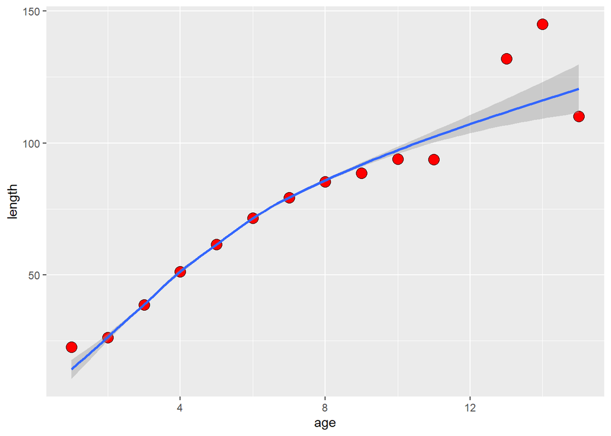

```r
ggplot(age_ordered, aes(x = age, y = length))+
  geom_point(data = fish_by_age, aes( y = Avg_length), size = 4,
           shape = 21, fill = "red")+
  geom_smooth(method = "loess")
```

The red dots represent the average for a given age.

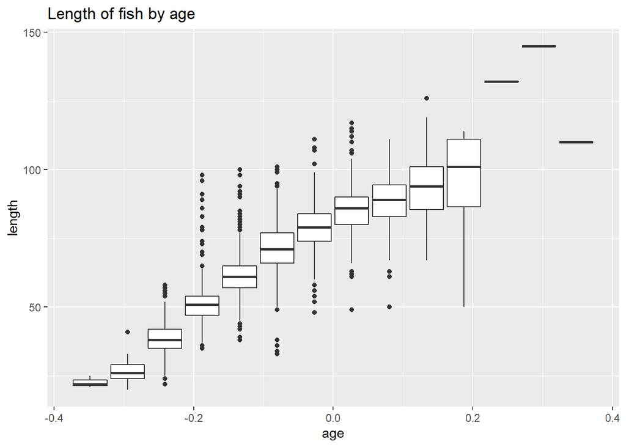

```r
ggplot(oo, aes(group=fish_age,y=fish_length)) +
  geom_boxplot() + labs(y="length", x="age", title="Length of fish by age")
```

One of the primary advantages to using the continuous plot is that it is tribial to estmate age or length of a fish from the same population if you know one or the other. Both do suffere from the shortcomings of the data itself but the continuous plot does try to interpolate the mean of the older fish based off the previous data however the accuracy of this estimate is questionable.

## d)

Now we create two dataframes with a sample of 50 fish from two random quadrants.

```r
#Creates a dataframe with 100 random fish from two random quadrants
#temp column
oo <- oo %>% mutate(quadrant_num = recode_factor
                    (quadrant, "NE"="1", "NW"="2",
                      "SW"="3", "SE"="4"))

#creates temp dataframe with random quadrants
set.seed(0601)
q1 = filter(oo, quadrant_num == toString(floor(runif(1, min=0, max=4))))
set.seed(0601)
q2 = filter(oo, quadrant_num == toString(ceiling(runif(1, min=1, max=5))))

#takes 50 random values from the temp dataframes
set.seed(0601)
q1 = sample_n(q1 ,50)
set.seed(0601)
q2 = sample_n(q2 ,50)
```

The assignment calls for a combined table of the two dataframes but we can just as well use the two different frames. However a combined table can be created with the following code.

```r
fish_tbl = rbind(q1, q2)
```

## e)

```r
#defines vectors of
area1 = subset(q1,  quadrant == q1$quadrant[25], fish_length,
                 drop = TRUE)
area2 = subset(q2,  quadrant == q2$quadrant[25], fish_length,
                drop = TRUE)

result = t.test(area1, area2, paired = TRUE)
```

## f)

To see if the length of the fish in each quadrant is normally distributed, we can plot, for each quadrant, the number of fish in certain ranges of lengths.

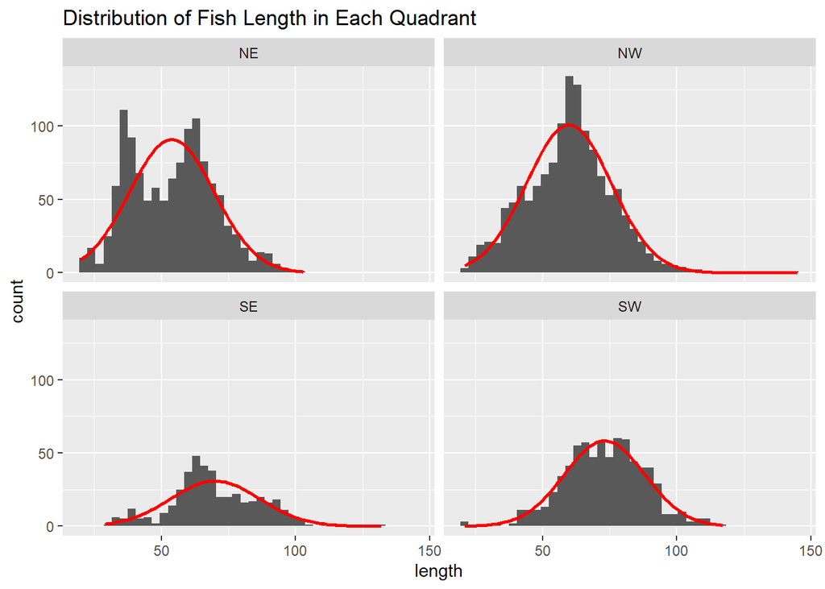

```r
#loading needed library and defines long format dataframe needed
library(reshape2)
oo_long = melt(oo, id.vars='quadrant', measure.vars='fish_length', value.name='fish_length')

#Function that takes vector and returns dataframe that contains the estimated normal #distribution of the vector

get_normal_density <- function(x, binwidth) {
  grid <- seq(min(x), max(x), length=100)
  data.frame(fish_length = grid,
    normal_curve = dnorm(grid, mean(x), sd(x)) * length(x) * binwidth
  )
}

# Creates normally distributed data for each quadrant
normaldens <-
  oo %>%
  group_by(quadrant) %>%
  do(get_normal_density(x=.$fish_length, binwidth=3))

ggplot() + geom_histogram(data=oo_long, aes(x=fish_length),binwidth=3)+
  geom_line(data=normaldens,mapping=aes(x=fish_length,y=normal_curve),col="red",size=1)+
  facet_wrap(~quadrant)+
  labs(x="length", title="Distribution of Fish Length in Each Quadrant")
```

```r
rm(get_normal_density, oo_long, normaldens)
```

As we can see, NW and SW follow a normal disribution fairly closely. SE is less clear in that the right tail is too big. The NE quadrant is problematic in that it has two clear peaks. Not something a normal distribution can accurately approximate.

## Bonus)

```r
theme_set(theme_dark())
library("sf")
library("rnaturalearth")##
library("rnaturalearthdata")##
world <- ne_countries(scale = "medium", returnclass = "sf")
class(world)
```

```
## [1] "sf"         "data.frame"
```

```r
reitir<-unique(oo$area)
x<-r2d(reitir)$lon
y<-r2d(reitir)$lat
sites <- data.frame(longitude=x, latitude = y)

## Icelandic map with fish coordinates (need to beautify, text overlaps)
ggplot(data = world) +
  geom_sf(color = "black", fill = "blue")+ # Black border and blue filling
  geom_point(data = sites, aes(x = longitude, y = latitude), size = 1,
             shape = 24, fill = "yellow") + # Trinangular shaped yellow marks
  labs(x="Longitude", y="Latitude",title="Iceland",
       subtitle = paste0("(", nrow(sites), " spots)"))+
  coord_sf(xlim = c(min(oo$long), max(oo$long)), ylim = c(min(oo$lat),max(oo$lat)), expand = TRUE)+
  geom_text(data=sites,aes(x=longitude,y=latitude,label= paste0("(", abs(x),",",y,")")),
          hjust=0, vjust=0, size=3,angle=30,
          colour="yellow",nudge_y=-0.12,nudge_x=-0.7)+
  ggsave("figure2b.jpg", dpi=1000, dev='png', height=8, width=10, units="in")
```

[figure not shown]

```r
rm(reitir, x, y, world, sites)
```